# Contraception après IVG

Noémie LERCH, JcB

13/12/2014

MAJ: 12/02/2015

# 1 Récupérer les données source

Le fichier **../Data/QUESTIONNAIRE PATIENTE 12.02.15.csv** contient **80** enregistrements.

# 2 Analyse descriptive univariée

## 2.1 Origine des données

```
CMCO  HTP
  27   53
```

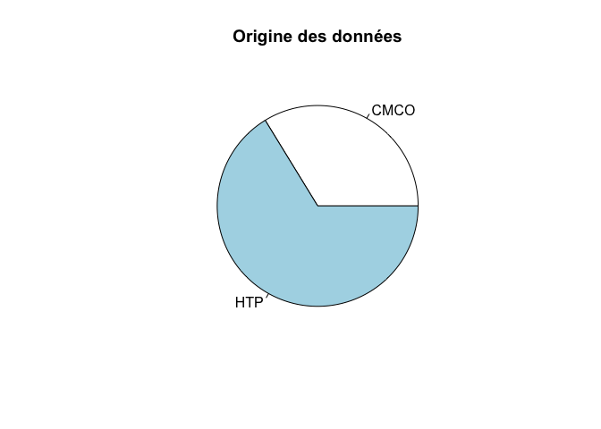

## 2.2 1. Age des participantes

```
   Min. 1st Qu.  Median    Mean 3rd Qu.    Max.    NA's
  15.00   19.25   24.00   25.88   32.00   44.00      22
```

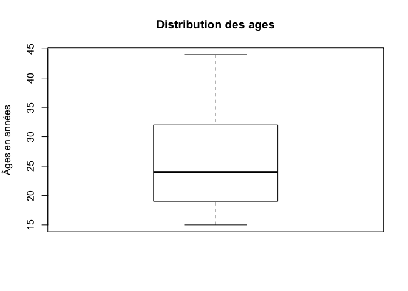

On souhaite représenter l’histogramme avec les classe d’age standard de la littérature:

```
age
[15,19] (19,24] (24,29] (29,34] (34,39] (39,44] (44,49]
     15      15       8      11       7       2       0
```

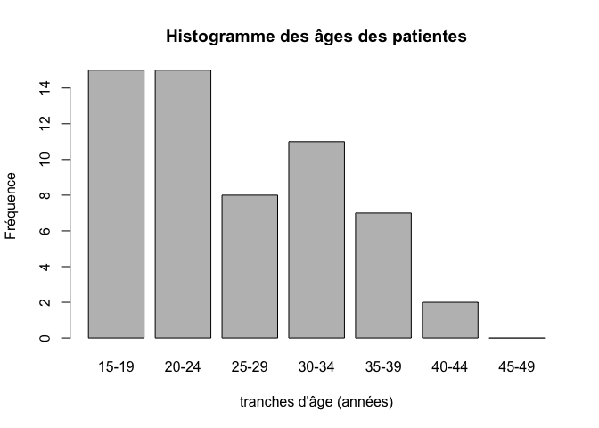

## 2.3 2. Niveau d’étude

```
   AUTRE      bac Bac +2/3   Bac +5  CAP/BEP  COLLEGE   JAMAIS     NA's
       1       20       13        2       14        7        1       22
```

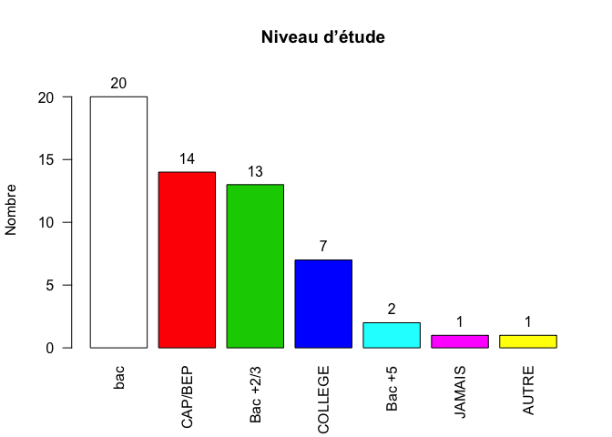

```
d$NIVEAU :
         Frequency   %(NA+)   %(NA-)
NA's            22     27.5      0.0
bac             20     25.0     34.5
CAP/BEP         14     17.5     24.1
Bac +2/3        13     16.2     22.4
COLLEGE          7      8.8     12.1
Bac +5           2      2.5      3.4
AUTRE            1      1.2      1.7
JAMAIS           1      1.2      1.7
  Total         80    100.0    100.0
```

## 2.4 3. Êtes-vous en couple ?

```
 NON  OUI NA's
  17   43   20
```

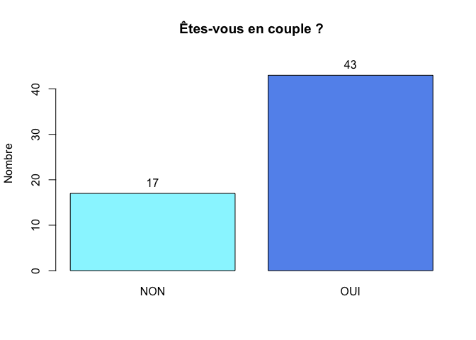

```
d$COUPLE :
        Frequency   %(NA+)   %(NA-)
NON            17     21.2     28.3
OUI            43     53.8     71.7
NA's           20     25.0      0.0
  Total        80    100.0    100.0
```

## 2.5 4. Avez-vous déjà été enceinte avant cette grossesse ?

```
 NON  OUI NA's
  25   35   20
```

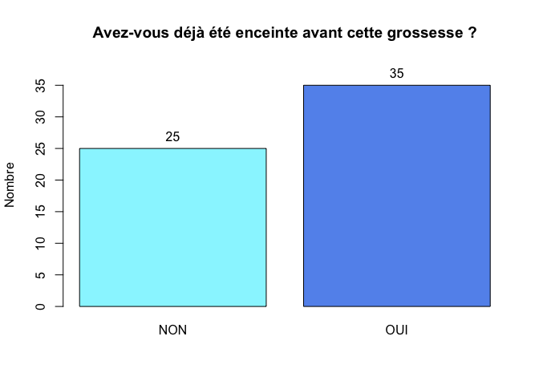

```
d$GROS_AVANT :
        Frequency   %(NA+)   %(NA-)
NON            25     31.2     41.7
OUI            35     43.8     58.3
NA's           20     25.0      0.0
  Total        80    100.0    100.0
```

## 2.6 Si oui, combien de fois ?

```
NB_ACC NB_FCS NB_IVG NB_IMG
    53      8     21      3
```

```
   Min. 1st Qu.  Median    Mean 3rd Qu.    Max.
  0.000   0.000   0.000   1.062   2.000   7.000
```

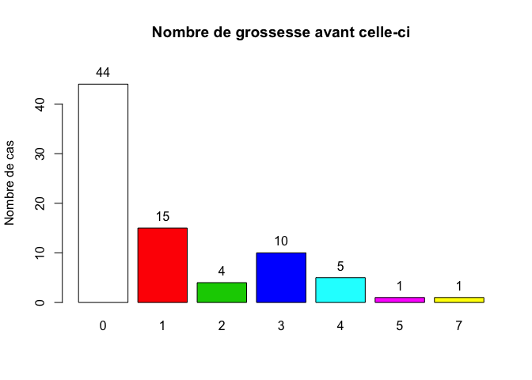

```
nb.de.fois :
        Frequency Percent Cum. percent
0              44    55.0         55.0
1              15    18.8         73.8
2               4     5.0         78.8
3              10    12.5         91.2
4               5     6.2         97.5
5               1     1.2         98.8
7               1     1.2        100.0
  Total        80   100.0        100.0
```

## 2.7 5. Combien d’enfants avez-vous ?

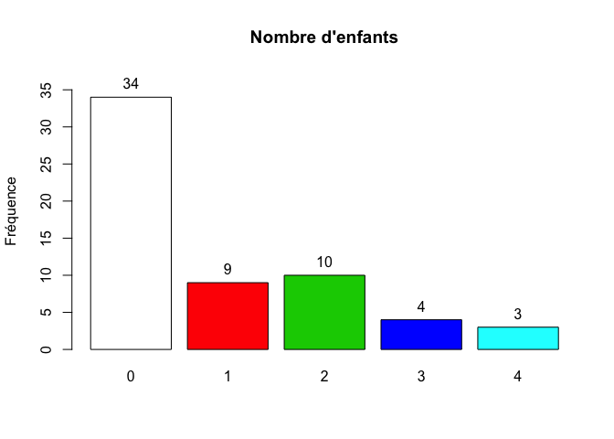

```
d$NB_ENFANTS :
        Frequency   %(NA+)   %(NA-)
0              34     42.5     56.7
1               9     11.2     15.0
2              10     12.5     16.7
3               4      5.0      6.7
4               3      3.8      5.0
NA's           20     25.0      0.0
  Total        80    100.0    100.0
```

## 2.8 6. Avez-vous un suivi gynécologique régulier

(au moins une consultation par an) ?

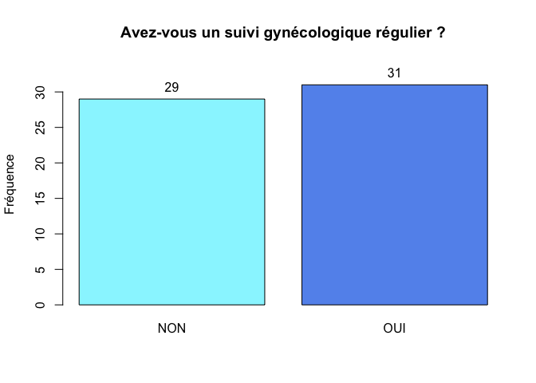

```
d$SUIVI :
        Frequency   %(NA+)   %(NA-)
NON            29     36.2     48.3
OUI            31     38.8     51.7
NA's           20     25.0      0.0
  Total        80    100.0    100.0
```

## 2.9 7. Quelle méthode a été envisagée pour l’IVG ?

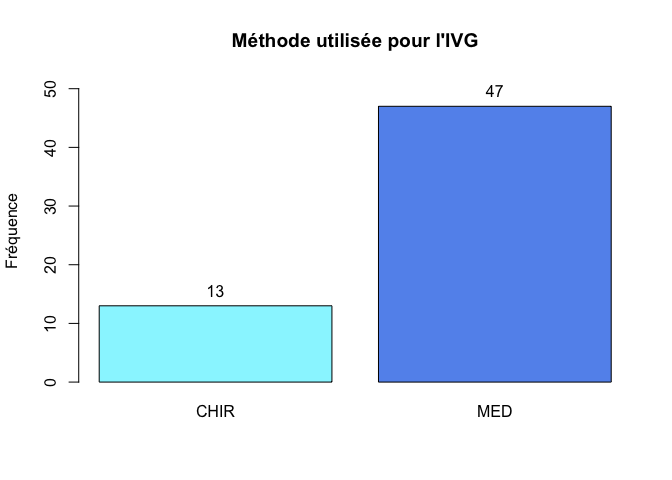

```
d$IVG :
        Frequency   %(NA+)   %(NA-)
CHIR           13     16.2     21.7
MED            47     58.8     78.3
NA's           20     25.0      0.0
  Total        80    100.0    100.0
```

## 2.10 8. Dans l’année précèdent votre grossesse, avez-vous changé de méthode de contraception ?

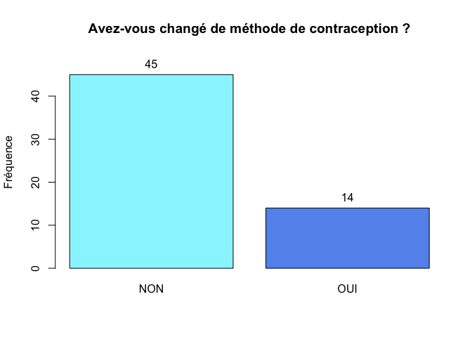

```
d$CHANGE :
        Frequency   %(NA+)   %(NA-)
NON            45     56.2     76.3
OUI            14     17.5     23.7
NA's           21     26.2      0.0
  Total        80    100.0    100.0
```

# 3 9. Quelle(s) est/sont la ou les dernière(s) méthode(s) contraceptive(s) que vous avez utilisée avant cette grossesse ?

#### 3.0.0.1 nombre de femmes utilisant chaque méthode contraceptive

```
     P     PM AUCUNE    IMP     PL     SC    AMC     SH
    34     13     11      6      6      2      2      1
```

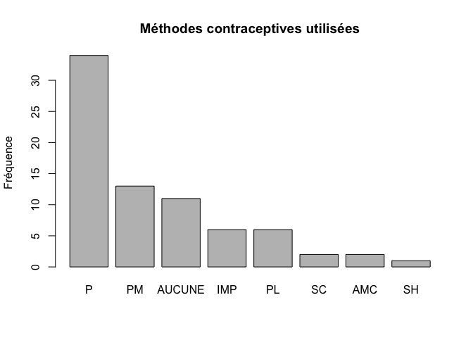

```
      P    PM AUCUNE IMP PL   SC  AMC   SH
N 34.00 13.00  11.00   6  6 2.00 2.00 1.00
% 45.33 17.33  14.67   8  8 2.67 2.67 1.33
```

Note: une femme pouvant utiliser plusieurs méthodes contraceptives simultannément, le total peut dépasser la taille de l’échantillon.

#### 3.0.0.2 nombre de méthode contraceptive utilisée par une femme

```
              1     2    3 NA's
Nb.de femmes 48  9.00 3.00   20
%            60 11.25 3.75   25
```

## 3.1 Depuis quand l’utilisez- vous ?

```
3_mois 0,5_an 8_mois   1_an  2_ans  3_ans  4_ans  5_ans  6_ans >8_ans
     1      7      1      5      7      5      5      2      1      1
 9_ans 11_ans  12_an   NA's
     2      1      1     41
```

## 3.2 10. Cette méthode contraceptive vous convenait-t-elle ?

```
 PAS_DU_TOUT PAS_VRAIMENT       PLUTOT  TOUT_A_FAIT         NA's
          13           21           12            6           28
```

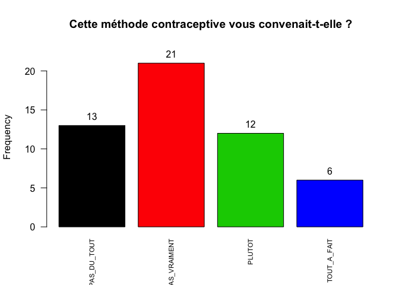

```
d$TOLERANCE :
             Frequency   %(NA+)   %(NA-)
PAS_DU_TOUT         13     16.2     25.0
PAS_VRAIMENT        21     26.2     40.4
PLUTOT              12     15.0     23.1
TOUT_A_FAIT          6      7.5     11.5
NA's                28     35.0      0.0
  Total             80    100.0    100.0
```

## 3.4 11. Cette grossesse est survenue suite à

Plusieurs réponses possibles (col 31 à 37)

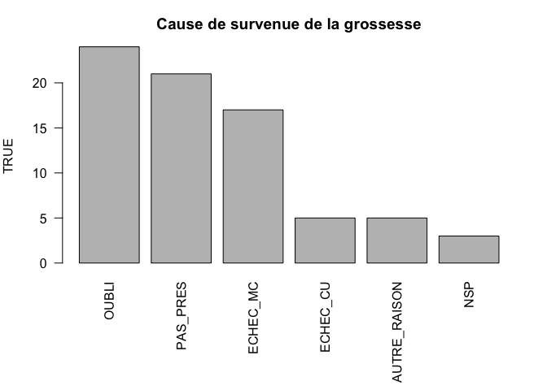

```r
cause <- d[, 31:37]
a <- lapply(cause, function(x){ifelse(is.na(x), "non", "oui")})
a <- as.data.frame(a)
x <- apply(a, 2, table)
b <- sapply(x, function(x){x[2]})
names(b) <- names(a)
par(mar = c(8, 4,3,2))
barplot(sort(b, decreasing = TRUE), main = "Cause de survenue de la grossesse", ylab = TRUE, las = 2)
```

## 3.5 12. Lors de votre demande d’IVG, avez-vous été informée sur les différents moyens de contraception ?

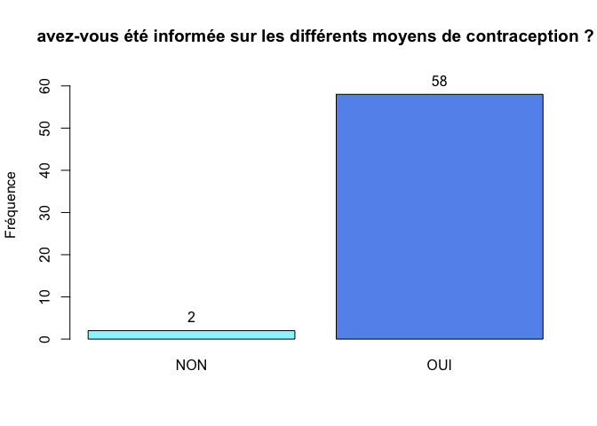

```
d$INFORMATION :
        Frequency   %(NA+)   %(NA-)
NON             2      2.5      3.3
OUI            58     72.5     96.7
NA's           20     25.0      0.0
  Total        80    100.0    100.0
```

## 3.6 13. Vous a-t-on prescrit une méthode de contraception ?

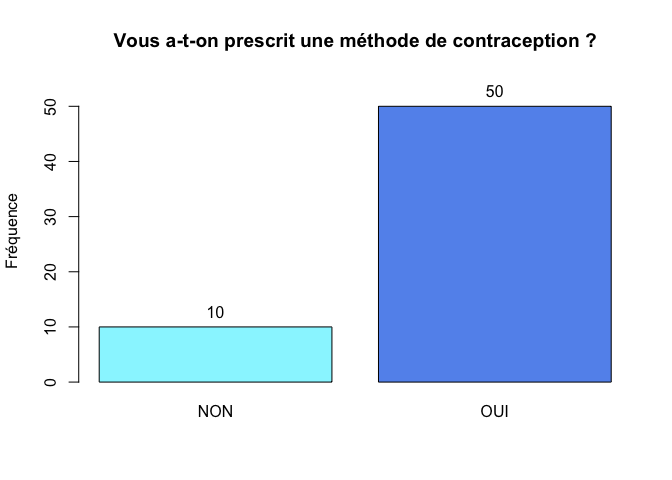

```
d$PRESCRIPTION :
        Frequency   %(NA+)   %(NA-)
NON            10     12.5     16.7
OUI            50     62.5     83.3
NA's           20     25.0      0.0
  Total        80    100.0    100.0
```

## 3.7 Si oui, laquelle ?

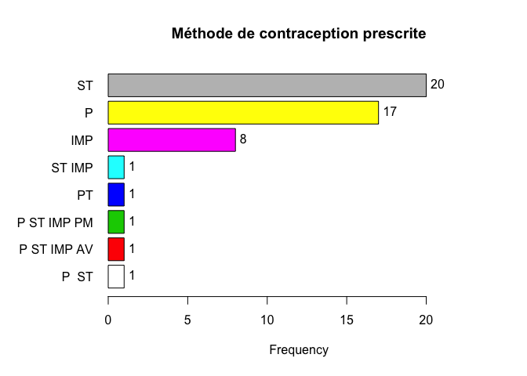

```
d$PRES_OUI[d$PRESCRIPTION == "OUI"] :
            Frequency   %(NA+)   %(NA-)
ST                 20     28.6       40
<NA>               20     28.6        0
P                  17     24.3       34
IMP                 8     11.4       16
P  ST               1      1.4        2
P ST IMP AV         1      1.4        2
P ST IMP PM         1      1.4        2
PT                  1      1.4        2
ST IMP              1      1.4        2
  Total            70    100.0      100
```

14. Avez-vous eu l’impression que le professionnel de santé a influencé votre choix ?

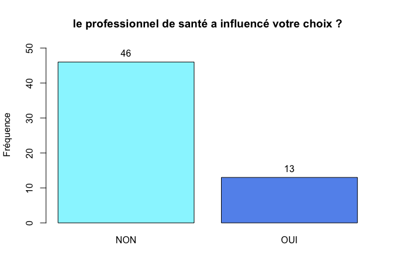

```
d$INFLUENCE :
        Frequency   %(NA+)   %(NA-)
NON            46     57.5       78
OUI            13     16.2       22
NA's           21     26.2        0
  Total        80    100.0      100
```

## 3.8 Si oui, avez-vous adhéré à sa proposition ?

Le “si oui” n’a pas ttoujours été respecté. Au moins une femme dit ne pas avoir été influencée mais n’accepte pas la proposition.

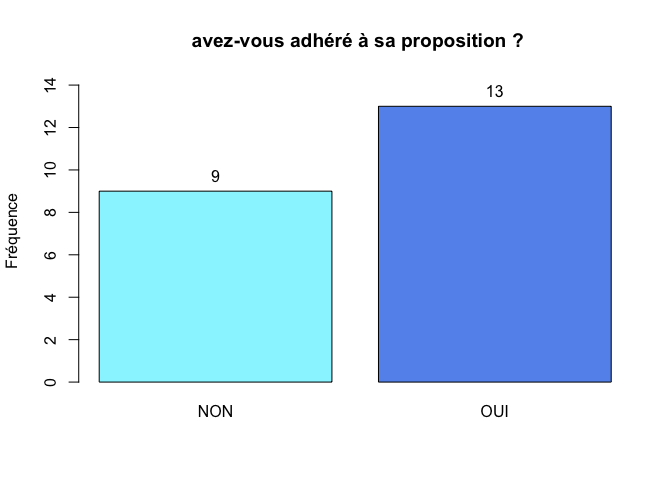

```
d$ACCEPTE :
        Frequency   %(NA+)   %(NA-)
NON             9     11.2     40.9
OUI            13     16.2     59.1
NA's           58     72.5      0.0
  Total        80    100.0    100.0
```

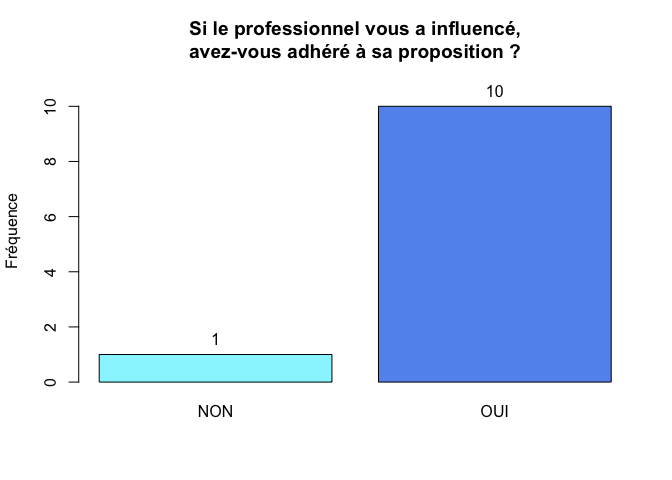

```
d$ACCEPTE[d$INFLUENCE == "OUI"] :
        Frequency   %(NA+)   %(NA-)
NON             1      2.9      9.1
OUI            10     29.4     90.9
NA's           23     67.6      0.0
  Total        34    100.0    100.0
```

## 3.9 15. Si vous n’adhérez pas à sa proposition, pourquoi ?

ATTENTION:

- non est écrit en minuscule (MAJUSCULE attendue)
- une réponse “pas envie” et “Accepte” = NA

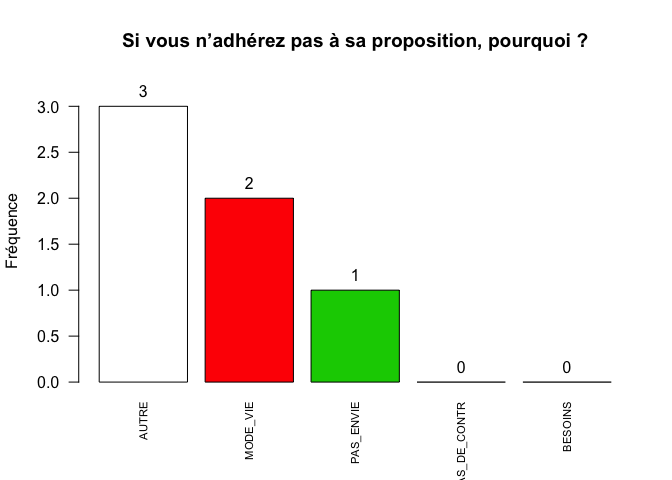

```
d$METHODE[d$ACCEPTE == "NON" & !is.na(d$ACCEPTE)] :
             Frequency   %(NA+)   %(NA-)
AUTRE                3     33.3     50.0
NA's                 3     33.3      0.0
MODE_VIE             2     22.2     33.3
PAS_ENVIE            1     11.1     16.7
BESOINS              0      0.0      0.0
PAS_DE_CONTR         0      0.0      0.0
  Total              9    100.0    100.0
```

## 3.11 16. À ce jour, quelle(s) méthode(s) de contraception avez-vous choisi?

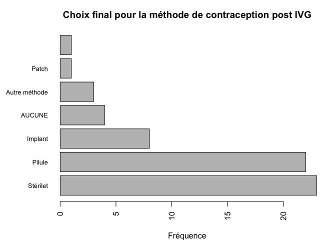

## 3.12 Evolution du choix de la méthode de contraception

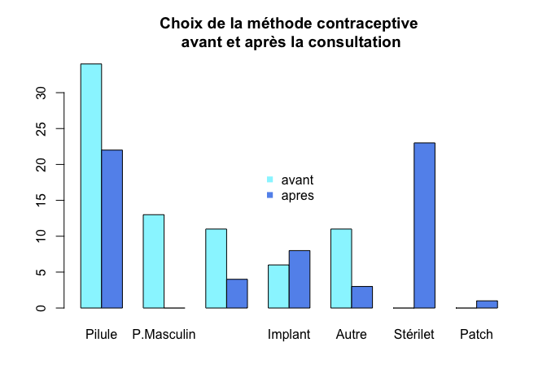

```
    Fisher's Exact Test for Count Data

data:  a
p-value = 6.237e-11
alternative hypothesis: two.sided
```